# APS1070

#### Project 1 --- Basic Principles and Models

**Deadline: Feb 2nd, 11PM - 10 percent**

**Academic Integrity**

This project is individual - it is to be completed on your own. If you have questions, please post your query in the APS1070 Piazza Q&A forums (the answer might be useful to others!).

Do not share your code with others, or post your work online. Do not submit code that you have not written yourself. Students suspected of plagiarism on a project, midterm or exam will be referred to the department for formal discipline for breaches of the Student Code of Conduct.

Name: **Abhishek Patel**

Student ID: **1009311031**

**Marking Scheme:**

This project is worth **10 percent** of your final grade.

Draw a plot or table where necessary to summarize your findings.

**Practice Vectorized coding**: If you need to write a loop in your solution, think about how you can implement the same functionality with vectorized operations. Try to avoid loops as much as possible (in some cases, loops are inevitable).

### How to submit **(HTML + IPYNB)**

1. Download your notebook: `File -> Download .ipynb`
2. Click on the Files icon on the far left menu of Colab
3. Select & upload your `.ipynb` file you just downloaded, and then obtain its path (right click) (you might need to hit the Refresh button before your file shows up)
1. execute the following in a Colab cell:

   ```
   %%shell
   jupyter nbconvert --to html /PATH/TO/YOUR/NOTEBOOKFILE.ipynb
   ```

2. An HTML version of your notebook will appear in the files, so you can download it.
3. Submit **both** `HTML` and `IPYNB` files on Quercus for grading.

Ref: https://stackoverflow.com/a/64487858

# Project 1 [10 Marks]

Let's apply the tools we have learned in the tutorial to a new dataset.

We're going to work with a [diabetes dataset](https://scikit-learn.org/stable/modules/generated/sklearn.datasets.load_diabetes.html). Download it using the cell below:

```python
import numpy as np
import pandas as pd

# Visualization
import matplotlib.pyplot as plt
import seaborn as sns
sns.set()

# Loading Dataset
from sklearn.datasets import load_diabetes

# Splitting Data into Train and Test data
from sklearn.model_selection import train_test_split

# Standardizing Data
from sklearn.preprocessing import StandardScaler

# Model Training and Cross-validation
from sklearn import neighbors
from sklearn.model_selection import cross_validate

# Feature Selection
from sklearn import tree

# Comparing model performance with another Classifier (Decision tree Classifier)
# ALong with it's Hyperparameter Tuning
from sklearn import model_selection

# Testing the Best Model out of all made
from sklearn import metrics
```

```python
dataset = load_diabetes()
# dataset
```

## Part 1: Getting started [2.5 Marks]

First off, take a look at the `data`, `target` and `feature_names` entries in the `dataset` dictionary. They contain the information we'll be working with here. Then, create a Pandas DataFrame called `df` containing the data and the targets, with the feature names as column headings. If you need help, see [here](https://pandas.pydata.org/pandas-docs/stable/reference/api/pandas.DataFrame.html) for more details on how to achieve this. **[0.4]**

- How many features do we have in this dataset? **10 Features**
- Determine the median target value. **Median Value = 140.5**
- How many participants have a target value greater than the median target value? **221 Participants**

Now add an additional column containing either 0 (if the target value is below the median) or 1 (if the target value is above the median). This will be the new target value to classify the data as "diabetes severity below median" or "diabetes severity above median". **[0.5]**

```python
print(dataset.feature_names)
print(len(dataset.feature_names))
print(np.median(dataset.target))
print(((dataset.target)>(np.median(dataset.target))).sum())
```

```
['age', 'sex', 'bmi', 'bp', 's1', 's2', 's3', 's4', 's5', 's6']
10
140.5
221
```

```python
Target = [int(item) for item in list(((dataset.target)>(np.median(dataset.target))))]
# Target
```

```python
df = pd.DataFrame(dataset.data, columns = dataset.feature_names)
df['target'] = Target
df
```

|  | age | sex | bmi | bp | s1 | s2 | s3 | s4 | s5 | s6 | target |
| --- | --- | --- | --- | --- | --- | --- | --- | --- | --- | --- | --- |
| 0 | 0.038076 | 0.050680 | 0.061696 | 0.021872 | -0.044223 | -0.034821 | -0.043401 | -0.002592 | 0.019907 | -0.017646 | 1 |
| 1 | -0.001882 | -0.044642 | -0.051474 | -0.026328 | -0.008449 | -0.019163 | 0.074412 | -0.039493 | -0.068332 | -0.092204 | 0 |
| 2 | 0.085299 | 0.050680 | 0.044451 | -0.005670 | -0.045599 | -0.034194 | -0.032356 | -0.002592 | 0.002861 | -0.025930 | 1 |
| 3 | -0.089063 | -0.044642 | -0.011595 | -0.036656 | 0.012191 | 0.024991 | -0.036038 | 0.034309 | 0.022688 | -0.009362 | 1 |
| 4 | 0.005383 | -0.044642 | -0.036385 | 0.021872 | 0.003935 | 0.015596 | 0.008142 | -0.002592 | -0.031988 | -0.046641 | 0 |
| ... | ... | ... | ... | ... | ... | ... | ... | ... | ... | ... | ... |
| 437 | 0.041708 | 0.050680 | 0.019662 | 0.059744 | -0.005697 | -0.002566 | -0.028674 | -0.002592 | 0.031193 | 0.007207 | 1 |
| 438 | -0.005515 | 0.050680 | -0.015906 | -0.067642 | 0.049341 | 0.079165 | -0.028674 | 0.034309 | -0.018114 | 0.044485 | 0 |
| 439 | 0.041708 | 0.050680 | -0.015906 | 0.017293 | -0.037344 | -0.013840 | -0.024993 | -0.011080 | -0.046883 | 0.015491 | 0 |
| 440 | -0.045472 | -0.044642 | 0.039062 | 0.001215 | 0.016318 | 0.015283 | -0.028674 | 0.026560 | 0.044529 | -0.025930 | 1 |
| 441 | -0.045472 | -0.044642 | -0.073030 | -0.081413 | 0.083740 | 0.027809 | 0.173816 | -0.039493 | -0.004222 | 0.003064 | 0 |

442 rows × 11 columns

### Splitting the data

It is best practice to have a training set (from which there is a rotating validation subset) and a test set. Our aim here is to (eventually) obtain the best accuracy we can on the test set (we'll do all our tuning on the training/validation sets, however.)

**Split the dataset** into a train and a test set **"70:30"**, use **`random_state=0`**. The test set is set aside (untouched) for final evaluation, once hyperparameter optimization is complete. **[0.5]**

**Only Split the dataset once within you notebook.** You should not use the `train_test_split` function more than once, regardless of the random state. Keep this in mind for your future projects as well.

```python
X_train, X_test, y_train, y_test = train_test_split(dataset.data, Target, test_size=0.3, random_state=0)
```

```python
df_train = pd.DataFrame(data = X_train, columns = dataset.feature_names)
df_train['target'] = y_train

df_test = pd.DataFrame(data = X_test, columns = dataset.feature_names)
df_test['target'] = y_test

print(df_train.shape)
print(df_test.shape)
```

```
(309, 11)
(133, 11)
```

```python
df_train
```

|  | age | sex | bmi | bp | s1 | s2 | s3 | s4 | s5 | s6 | target |
| --- | --- | --- | --- | --- | --- | --- | --- | --- | --- | --- | --- |
| 0 | 0.012648 | 0.050680 | 0.000261 | -0.011420 | 0.039710 | 0.057245 | -0.039719 | 0.056081 | 0.024055 | 0.032059 | 1 |
| 1 | -0.027310 | -0.044642 | -0.066563 | -0.112399 | -0.049727 | -0.041397 | 0.000779 | -0.039493 | -0.035816 | -0.009362 | 0 |
| 2 | 0.005383 | -0.044642 | 0.059541 | -0.056177 | 0.024574 | 0.052861 | -0.043401 | 0.050914 | -0.004222 | -0.030072 | 0 |
| 3 | 0.030811 | 0.050680 | 0.056307 | 0.076958 | 0.049341 | -0.012274 | -0.036038 | 0.071210 | 0.120051 | 0.090049 | 1 |
| 4 | 0.009016 | -0.044642 | -0.024529 | -0.026328 | 0.098876 | 0.094196 | 0.070730 | -0.002592 | -0.021395 | 0.007207 | 0 |
| ... | ... | ... | ... | ... | ... | ... | ... | ... | ... | ... | ... |
| 304 | 0.070769 | 0.050680 | -0.007284 | 0.049415 | 0.060349 | -0.004445 | -0.054446 | 0.108111 | 0.129021 | 0.056912 | 1 |
| 305 | 0.056239 | 0.050680 | -0.030996 | 0.008101 | 0.019070 | 0.021233 | 0.033914 | -0.039493 | -0.029526 | -0.059067 | 0 |
| 306 | 0.059871 | -0.044642 | -0.021295 | 0.087287 | 0.045213 | 0.031567 | -0.047082 | 0.071210 | 0.079122 | 0.135612 | 1 |
| 307 | -0.078165 | -0.044642 | -0.073030 | -0.057313 | -0.084126 | -0.074277 | -0.024993 | -0.039493 | -0.018114 | -0.083920 | 1 |
| 308 | 0.041708 | 0.050680 | 0.071397 | 0.008101 | 0.038334 | 0.015909 | -0.017629 | 0.034309 | 0.073407 | 0.085907 | 1 |

309 rows × 11 columns

### Effect of Standardization (Visual)

Use `seaborn.lmplot` ([help here](https://seaborn.pydata.org/generated/seaborn.lmplot.html)) to visualize a few features of the training set. Draw a plot where the x-axis is `age`, the y-axis is `bmi,` and the color of each datapoint indicates its class. **[0.5]**

Standardizing the data is often critical in machine learning. Show a plot as above, but standardize the two features. What's different? **why do they look similar?** Based on your observation, what is the advantage of standardization? **[0.6]**

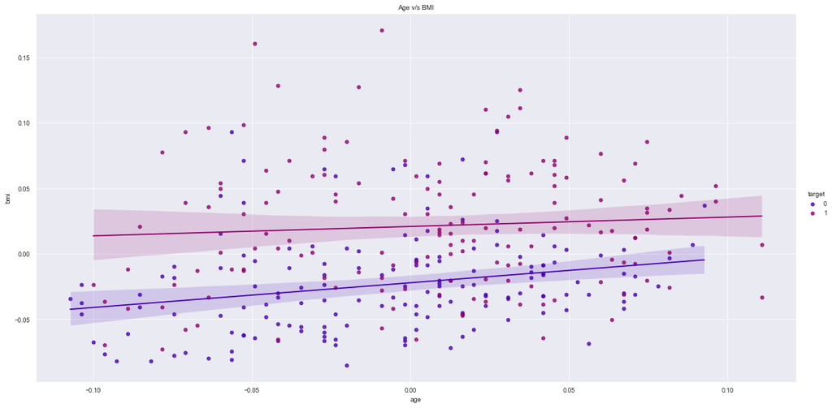

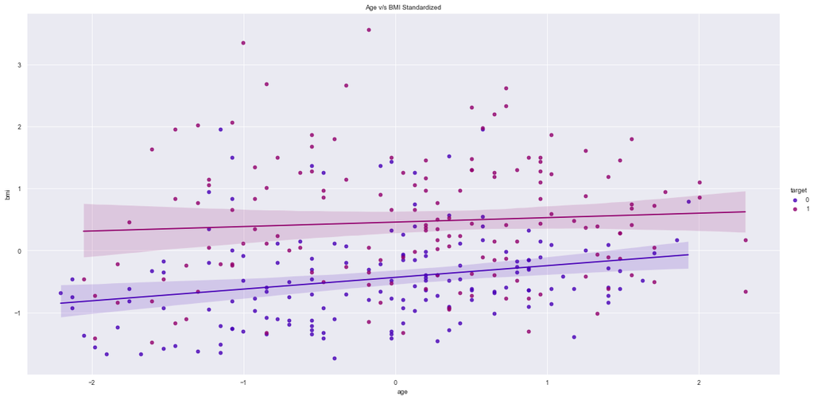

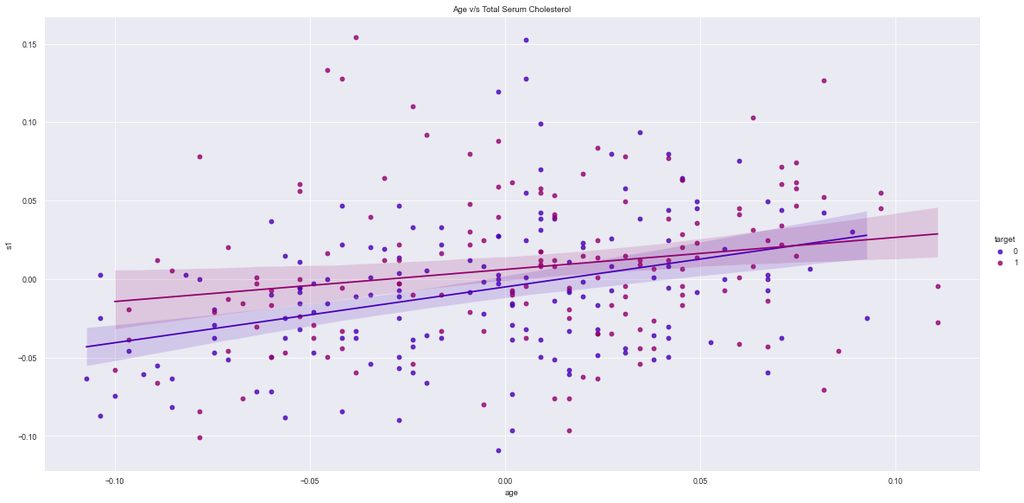

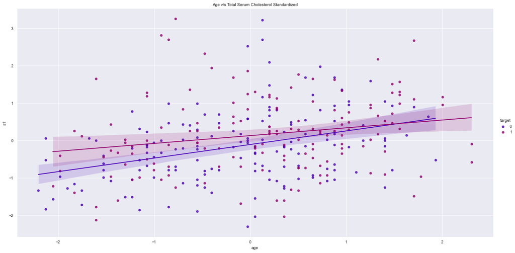

```python
# fig, axes = plt.subplots(1, 2, figsize = (17,10))

sns.set_theme(context='paper', style='darkgrid', palette='brg', font='sans-serif', font_scale=1, color_codes=True)
plot1 = sns.lmplot(x='age', y='bmi', data=df_train, hue='target', height = 8, aspect = 2).set(title = 'Age v/s BMI')

scaler = StandardScaler()
X_train_std = scaler.fit_transform(X_train)

df_train_std = pd.DataFrame(data = X_train_std, columns = dataset.feature_names)
df_train_std['target'] = y_train

# df_train_std

sns.set_theme(context='paper', style='darkgrid', palette='brg', font='sans-serif', font_scale=1, color_codes=True)
plot2 = sns.lmplot(x='age', y='bmi', data=df_train_std, hue='target', height = 8, aspect = 2).set(title = 'Age v/s BMI Standardized')

sns.set_theme(context='paper', style='darkgrid', palette='brg', font='sans-serif', font_scale=1, color_codes=True)
plot3 = sns.lmplot(x='age', y='s1', data=df_train, hue='target', height = 8, aspect = 2).set(title = 'Age v/s Total Serum Cholesterol')

sns.set_theme(context='paper', style='darkgrid', palette='brg', font='sans-serif', font_scale=1, color_codes=True)
plot4 = sns.lmplot(x='age', y='s1', data=df_train_std, hue='target', height = 8, aspect = 2).set(title = 'Age v/s Total Serum Cholesterol Standardized')
```

The scales for both features have been `standardized` *(by subtracting the column mean and dividing by the column standard deviation)*, thus **centering all the scales to 0.** It also rendered each feature with no units, so we wouldn't have worry about conversions and it's interferance with the data modelling.

## Part 2: KNN Classifier without Standardization [2 Marks]

Normally, standardizing data is a key step in preparing data for a KNN classifier. However, for educational purposes, let's first try to build a model without standardization. Let's create a KNN classifier to predict whether a patient has a diabetes severity that is less than the median or greater than the median.

Follow these steps:

1. Train a KNN Classifier using cross-validation on the dataset. Sweep `k` (number of neighbours) from 1 to 100, and show a plot of the mean cross-validation accuracy vs `k`. **[1]**
2. What is the best `k`? What is the highest cross-validation accuracy? **[0.5]**
3. Comment on which ranges of `k` lead to underfitted or overfitted models (hint: compare training and validation curves!). **[0.5]**

```
Best k =  15
Best Mean Validation Accuracy =  0.7542570068746695
```

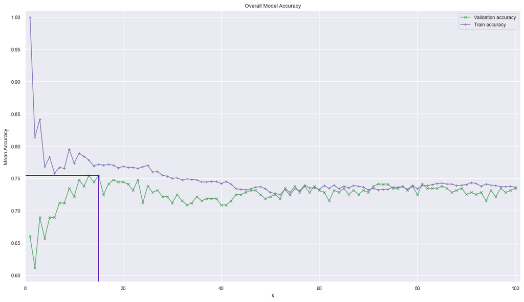

```python
# Empty lists for storing the scores (Train and Validation)
train_scores = []
validation_scores = []

index = 0

# Training the model for different number of neighbors (1-100)
for k in range(1,101,1):
    knn = neighbors.KNeighborsClassifier(n_neighbors=k)
    scores = cross_validate(knn, X_train, y_train, cv=5, return_train_score=True)
    train_scores.append(scores['train_score'].mean())
    validation_scores.append(scores['test_score'].mean())
#     print('k = ',k,
#           ' Mean Train Accuracy = ', train_scores[k-1],
#           ' Mean Validation Accuracy = ', validation_scores[k-1])

#     For finding the best neighbor
    if (validation_scores[k-1]) > (validation_scores[index]):
        index = k - 1

print('Best k = ', index+1)
print('Best Mean Validation Accuracy = ', validation_scores[index])

# Plotting the train and validation accuracies
plt.figure(figsize = (16,9), dpi = 100)
plt.ylim(0.59,1.01)
plt.xlim(0,101)
plt.plot([i for i in range(1,101)], validation_scores, '-gx', label = 'Validation accuracy', )
plt.plot([i for i in range(1,101)], train_scores, '-m+', label = 'Train accuracy')
# Plotting the vertical and horizontal line for the best k
plt.axvline(x = 15, ymax = 0.3912570068746695)
plt.axhline(y = 0.7542570068746695, xmax = 0.149)
plt.xlabel('k')
plt.ylabel('Mean Accuracy')
plt.title('Overall Model Accuracy')

plt.plot()
plt.legend()
```

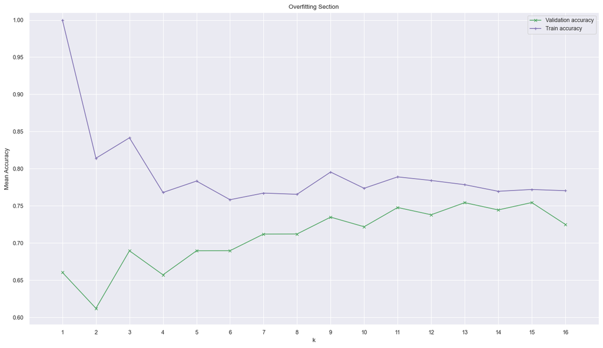

```python
# Finding the Overfitting Region
plt.figure(figsize = (16,9), dpi = 100)
plt.ylim(0.59,1.01)
plt.xlim(0,17)
plt.xticks(ticks = [i for i in range(1,17)])
plt.plot([i for i in range(1,17)], validation_scores[:16], '-gx', label = 'Validation accuracy', )
plt.plot([i for i in range(1,17)], train_scores[:16], '-m+', label = 'Train accuracy')
# Plotting the vertical and horizontal line for the best k
# plt.axvline(x = 15, ymax = 0.3912570068746695)
# plt.axhline(y = 0.7542570068746695, xmax = 0.149)
plt.xlabel('k')
plt.ylabel('Mean Accuracy')
plt.title('Overfitting Section')

plt.plot()
plt.legend()
```

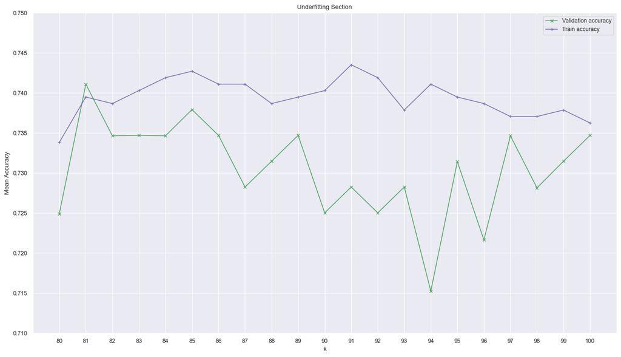

```python
# Finding the Underfitting Region
plt.figure(figsize = (16,9), dpi = 100)
plt.ylim(0.71,0.75)
plt.xlim(79,101)
plt.xticks(ticks = [i for i in range(80,101)])
plt.plot([i for i in range(80,101)], validation_scores[79:], '-gx', label = 'Validation accuracy', )
plt.plot([i for i in range(80,101)], train_scores[79:], '-m+', label = 'Train accuracy')
# Plotting the vertical and horizontal line for the best k
# plt.axvline(x = 15, ymax = 0.3912570068746695)
# plt.axhline(y = 0.7542570068746695, xmax = 0.149)
plt.xlabel('k')
plt.ylabel('Mean Accuracy')
plt.title('Underfitting Section')

plt.plot()
plt.legend()
```

**Overfitting Model:** The **range[1-16]** provides the model which is overfit as the training accuracy is consistantly significantly higher than the validation accuracy.

**Underfitting Model:** The **range[80-100]** provides the model which is underfit as the training accuracy and the validation accuracy is consistantly below the highest overall validation accuracy.

## Part 3: Feature Selection [3 Marks]

In this part, we aim to investigate the importance of each feature on the final classification accuracy. If we want to try every possible combination of features, we would have to test $2^F$ different cases, where F is the number of features, and in each case, we have to do a hyperparameter search (finding K, in KNN using cross-validation). That will take days!.

To find more important features we will use a decision tree. based on a decision tree we can compute feature importance that is a metric for our feature selection (code is provided below).

You can use [this link](https://machinelearningmastery.com/calculate-feature-importance-with-python/) to get familiar with extracting the feature impotance order of machine learning algorithms in Python.

After we identified and removed the least important feature and evaluated a new KNN model on the new set of features, if the stop conditions (see step 7 below) are not met, we need to repeat the process and remove another feature.

Design a function ( `Feature_selector`) that accepts your dataset (X_train , y_train) and a threshold as inputs and: **[1]**

1. Fits a decision tree classifier on the training set.
2. Extracts the feature importance order of the decision tree model.
3. Removes the least important feature based on step 2.
4. Then, a KNN model is trained on the remaining features. The number of neighbors (`k`) for each KNN model should be tuned using a 5-fold cross-validation.
5. Store the best `mean cross-validation` score and the corresponding `k` (number of neighbours) value in two lists.
6. Go back to step 3 and follow all the steps until you meet the stop condition (step 7).
7. We will stop this process when (1) there is only one feature left, or (2) our cross-validation accuracy is dropped significantly compared to a model that uses all the features. In this function, we accept a threshold as an input argument. For example, if threshold=0.95 we do not continue removing features if our mean cross-validation accuracy after tuning `k` is bellow **0.95 $\times$ Full Feature cross-validation accuracy**.
8. Your function returns the list of removed features, and the corresponding mean cross-validation accuracy and `k` value when a feature was removed.
- Visualize your results by plotting the mean cross-validation accuracy (with a tuned `k` on y axis) vs. the on the number of features (x axis). This plot describes: what is the best cv score with 1 feature, 2 features, 3 features ... and all the features. **[0.5]**
- Plot the best value of `k` (y-axis) vs. the number of features. This plot explains the trend of number of neighbours with respect to the number of features. **[0.5]**
- State what is the number of essential features for classification and justify your answer. **[1]**

You can use the following piece of code to start training a decision tree classifier and obtain its feature importance order.

```
from sklearn import tree
dt = tree.DecisionTreeClassifier()
dt.fit(X_train,y_train)
importance = dt.feature_importances_
```

```
[8 5 2 6 0 9 4 3 7 1]
['s5', 's2', 'bmi', 's3', 'age', 's6', 's1', 'bp', 's4', 'sex']
```

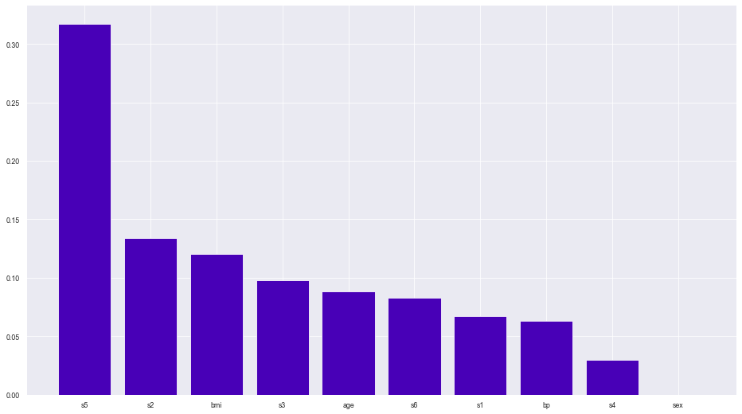

```python
dt = tree.DecisionTreeClassifier()
dt.fit(X_train,y_train)
importance = dt.feature_importances_

indices = np.argsort(importance)[::-1]
print(indices)
names = [dataset.feature_names[i] for i in indices]
print(names)
# for i,v in enumerate(importance):
#     print('Feature: %0d, Score: %.5f' % (i,v))
# plot feature importance
plt.figure(figsize = (16,9))
# plt.bar([x for x in range(len(importance))], importance)
plt.bar(range(X_train.shape[1]), importance[indices])
plt.xticks(range(X_train.shape[1]), names)
plt.show()
```

```python
pd.DataFrame(data = [importance[indices]], columns = dataset.feature_names)
```

[output not shown]

```python
def Feature_selector (X_train , y_train , tr=0.95):

    # Find Cross Validation Accuracy with All Features.
    best_full_cv_accuracy = []
    index = 0

    for k in range(1,101):
        knn = neighbors.KNeighborsClassifier(n_neighbors = k)
        scores = cross_validate(knn,
                                X_train,
                                y_train,
                                cv = 5,
                                return_train_score = True)
        best_full_cv_accuracy.append(scores['test_score'].mean())

        if (best_full_cv_accuracy[k-1]) > (best_full_cv_accuracy[index]):
            index = k - 1

    max_full_cv_accuracy = max(best_full_cv_accuracy)  # Full Feature cross-validation accuracy.

    print("Max Model Accuracy with all Features is ", max_full_cv_accuracy)
    print("Best K for Model with all Features is ", index+1)

    # Fit the decision tree and extract feature importance.
    dt = tree.DecisionTreeClassifier(random_state=0)
    dt.fit(X_train, y_train)
    importance = dt.feature_importances_

    importance_df = pd.Series(importance, index = dataset.feature_names).sort_values() # To drop least important features later
    X_train_fs = pd.DataFrame(X_train, columns= dataset.feature_names) # Drop least important features later b4 running
    features = 10


    # List to store mean cross-validation accuracy and corresponding k and the least important features.
    Best_Model_Accuracy = []
    Best_K = []
    Least_IMP_Features_list = []

    # While loop for dropping features.
    while features > 1:

        cv_accuracies = [] # Temporary list for collecting the accuracies

        # For loop for selecting k
        for k in range(1,101):
            knn = neighbors.KNeighborsClassifier(n_neighbors = k)
            scores = cross_validate(knn,
                                    X_train_fs.values,
                                    y_train,
                                    cv = 5,
                                    return_train_score = True)
            cv_accuracies.append(scores['test_score'].mean())

        max_tmp_cv_accuracy = max(cv_accuracies)
        max_tmp_k = cv_accuracies.index(max(cv_accuracies))+1

        # Removes features if.....
        if max_tmp_cv_accuracy < tr*max_full_cv_accuracy:

            break

        else:

            Best_Model_Accuracy.append(max_tmp_cv_accuracy)
            Best_K.append(max_tmp_k)
            Least_IMP_Features_list.append(importance_df.nsmallest(1).index[0])

            X_train_fs = X_train_fs.drop([importance_df.nsmallest(1).index[0]], axis='columns')
            importance_df = importance_df.drop(importance_df.nsmallest(1).index[0])

            features -= 1

    return Best_Model_Accuracy, Best_K, Least_IMP_Features_list


# Main calling of Function HERE!!
Best_Model_Accuracy_list, Best_K_list, Least_IMP_Features_list = Feature_selector (X_train , y_train , tr=0.95)
```

```
Max Model Accuracy with all Features is  0.7542570068746695
Best K for Model with all Features is  15
```

```python
Best_Model_Accuracy_list.insert(0, 0.7542570068746695)
Best_K_list.insert(0, 15)
Least_IMP_Features_list.insert(0, 'None')
```

```python
print(Best_K_list)
print(Best_Model_Accuracy_list)
print(Least_IMP_Features_list)
```

```
[15, 15, 25, 91, 99, 73, 7, 19, 60, 82]
[0.7542570068746695, 0.7542570068746695, 0.7671602326811211, 0.7539925965097833, 0.7540983606557378, 0.7574299312533052, 0.7540454785827604, 0.7637757800105763, 0.7540983606557378, 0.7248545742993127]
['None', 's4', 'sex', 's1', 's6', 'bp', 'age', 's3', 'bmi', 's2']
```

```python
Best_Model_Accuracy = np.array(Best_Model_Accuracy_list)
Best_K = np.array(Best_K_list)
Least_IMP_Features = np.array(Least_IMP_Features_list)

Best_Model_Accuracy = np.reshape(Best_Model_Accuracy, (Best_Model_Accuracy.shape[0],1))
Best_K = np.reshape(Best_K, (Best_K.shape[0],1))
Least_IMP_Features = np.reshape(Least_IMP_Features, (Least_IMP_Features.shape[0],1))

Feature_num = np.array([10,9,8,7,6,5,4,3,2,1])
Feature_num = np.reshape(Feature_num, (Feature_num.shape[0],1))


# Dataframe with the 3 lists merged together in order of feature removal.
removal_order = np.concatenate((Least_IMP_Features, Feature_num, Best_K, Best_Model_Accuracy), axis = 1)

df_removal_order = pd.DataFrame(removal_order, columns = ['Feature Removed', 'Number of Features', 'Best K', 'Model Acc'])
df_removal_order.set_index('Feature Removed', drop='Feature Removed', inplace = True)
df_removal_order['Number of Features'] = df_removal_order['Number of Features'].astype(int)
df_removal_order['Best K'] = df_removal_order['Best K'].astype(int)
df_removal_order['Model Acc'] = df_removal_order['Model Acc'].astype(float)
df_removal_order.sort_values('Number of Features', ascending = False, inplace = True)

df_removal_order
```

| Feature Removed | Number of Features | Best K | Model Acc |
| --- | --- | --- | --- |
| None | 10 | 15 | 0.754257 |
| s4 | 9 | 15 | 0.754257 |
| sex | 8 | 25 | 0.767160 |
| s1 | 7 | 91 | 0.753993 |
| s6 | 6 | 99 | 0.754098 |
| bp | 5 | 73 | 0.757430 |
| age | 4 | 7 | 0.754045 |
| s3 | 3 | 19 | 0.763776 |
| bmi | 2 | 60 | 0.754098 |
| s2 | 1 | 82 | 0.724855 |

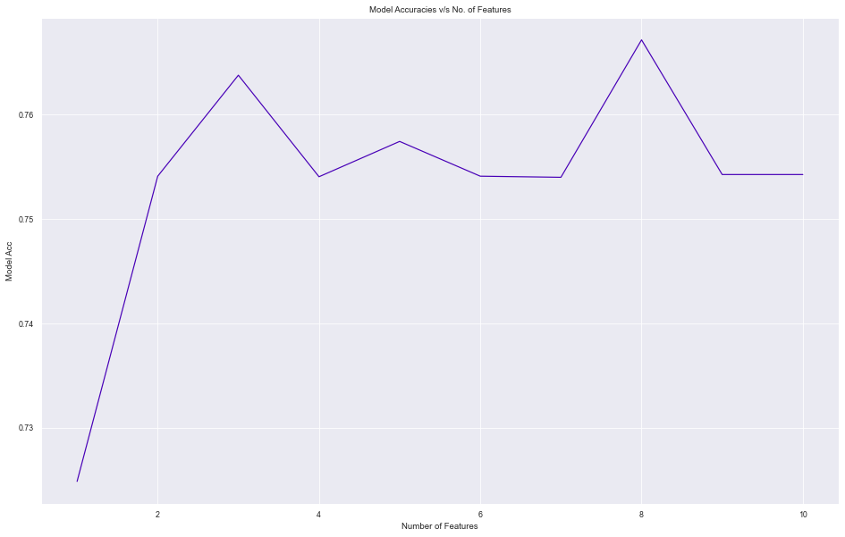

```python
plt.figure(figsize=(16,10))
plot5 = sns.lineplot(x= 'Number of Features', y= 'Model Acc', data= df_removal_order).set(title = 'Model Accuracies v/s No. of Features')
```

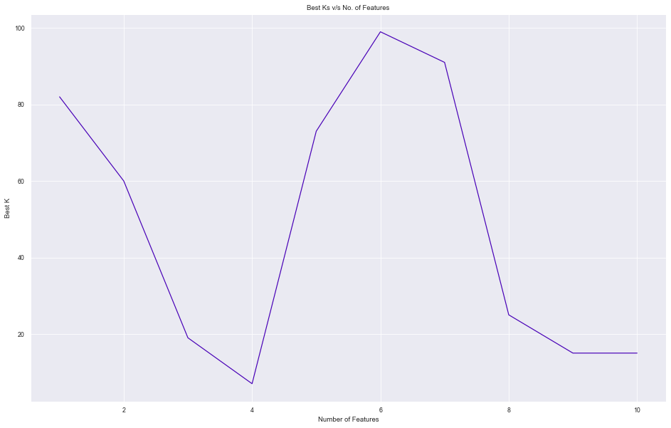

```python
plt.figure(figsize=(16,10))
plot6 = sns.lineplot(x= 'Number of Features', y= 'Best K', data= df_removal_order).set(title = 'Best Ks v/s No. of Features')
```

Looking at the overall model accuracies, there are 3 peaks in the Figure **'Model Accuracies v/s No. of Features'.**

The accuracies are more or less constant when we have a model with 10(all) features through having a model with only 4 features, however with 2 intermediate peaks at a model with:

```
        8 features (Model accuracy greatly improved by roughly 1%)

                                    **AND**

        5 features (Model accuracy improved very slightly to approx. 75.8% from 75.4%)
```

After these peaks there is an increase in model accuracy and a huge decrease in model features required to achieve this accuracy, however it is not as big as the one observed in the model with 8 features, altough still significant enough to train this model as the amount of data that will be required to train and generalize the model well is significantly less. `Less Features (Only IMP features) require Less samples of data to train the model`.

Thus it would be better to sacrifice only a fraction of accuracy for the amount of features. Therefore the **Essential Number of Features is 3.**

## Part 4: Standardization [1 Marks]

Standardizing the data usually means scaling our data to have a mean of zero and a standard deviation of one.

**Note:** When we standardize a dataset, do we care if the data points are in our training set or test set? Yes! The training set is available for us to train a model - we can use it however we want. The test set, however, represents a subset of data that is not available for us during training. For example, the test set can represent the data that someone who bought our model would use to see how the model performs (which they are not willing to share with us). Therefore, we cannot compute the mean or standard deviation of the whole dataset to standardize it - we can only calculate the mean and standard deviation of the training set. However, when we sell a model to someone, we can say what our scalers (mean and standard deviation of our training set) was. They can scale their data (test set) with our training set's mean and standard deviation. Of course, there is no guarantee that the test set would have a mean of zero and a standard deviation of one, but it should work fine.

**To summarize: We fit the StandardScaler only on the training set. We transform both training and test sets with that scaler.**

1. Standardize the training and test data ([Help](https://scikit-learn.org/stable/modules/preprocessing.html))
2. Call your `Feature_selector` function on the standardized training data with a threshold of 95\%.
   - Plot the Cross validation accuracy when we have the standardized data (this part) and the original training data (last part) vs. the Number of features in a single plot (to compare them easily).
3. Discuss how standardization affected your model and its performance?

```python
scaler = StandardScaler()
X_train_std = scaler.fit_transform(X_train)
X_test_std = scaler.fit_transform(X_test)

df_train_std = pd.DataFrame(data=X_train_std, columns=dataset.feature_names)
df_train_std['target'] = y_train

df_test_std = pd.DataFrame(data=X_test_std, columns=dataset.feature_names)
df_test_std['target'] = y_test

# df_train_std
# df_test_std
```

```python
Best_Model_Accuracy_std_list, Best_K_std_list, Least_IMP_Features_std_list = Feature_selector (X_train_std , y_train , tr=0.95)
```

```
Max Model Accuracy with all Features is  0.754151242728715
Best K for Model with all Features is  13
```

```python
Best_Model_Accuracy_std_list.insert(0, 0.754151242728715)
Best_K_std_list.insert(0, 13)
Least_IMP_Features_std_list.insert(0, 'None')
```

```python
print(Best_K_std_list)
print(Best_Model_Accuracy_std_list)
print(Least_IMP_Features_std_list)
```

```
[13, 13, 15, 90, 24, 77, 7, 41, 60, 28]
[0.754151242728715, 0.754151242728715, 0.7638286620835537, 0.7539925965097832, 0.7573241671073507, 0.7638286620835537, 0.7540454785827604, 0.7605499735589636, 0.7540983606557378, 0.7281332628239026]
['None', 's4', 'sex', 's1', 's6', 'bp', 'age', 's3', 'bmi', 's2']
```

```python
Best_Model_Accuracy_std = np.array(Best_Model_Accuracy_std_list)
Best_K_std = np.array(Best_K_std_list)
Least_IMP_Features_std = np.array(Least_IMP_Features_std_list)

Best_Model_Accuracy_std = np.reshape(Best_Model_Accuracy_std, (Best_Model_Accuracy_std.shape[0],1))
Best_K_std = np.reshape(Best_K_std, (Best_K_std.shape[0],1))
Least_IMP_Features_std = np.reshape(Least_IMP_Features_std, (Least_IMP_Features_std.shape[0],1))

Feature_num_std = np.array([10,9,8,7,6,5,4,3,2,1])
Feature_num_std = np.reshape(Feature_num_std, (Feature_num_std.shape[0],1))


# Dataframe with the 3 lists merged together in order of feature removal.
removal_order_std = np.concatenate((Least_IMP_Features_std, Feature_num_std, Best_K_std, Best_Model_Accuracy_std), axis = 1)

df_removal_order_std = pd.DataFrame(removal_order_std, columns = ['Feature Removed', 'Number of Features', 'Best K', 'Model Acc'])
df_removal_order_std.set_index('Feature Removed', drop='Feature Removed', inplace = True)
df_removal_order_std['Number of Features'] = df_removal_order_std['Number of Features'].astype(int)
df_removal_order_std['Best K'] = df_removal_order_std['Best K'].astype(int)
df_removal_order_std['Model Acc'] = df_removal_order_std['Model Acc'].astype(float)
df_removal_order_std.sort_values('Number of Features', ascending = False, inplace = True)

df_removal_order_std
```

| Feature Removed | Number of Features | Best K | Model Acc |
| --- | --- | --- | --- |
| None | 10 | 13 | 0.754151 |
| s4 | 9 | 13 | 0.754151 |
| sex | 8 | 15 | 0.763829 |
| s1 | 7 | 90 | 0.753993 |
| s6 | 6 | 24 | 0.757324 |
| bp | 5 | 77 | 0.763829 |
| age | 4 | 7 | 0.754045 |
| s3 | 3 | 41 | 0.760550 |
| bmi | 2 | 60 | 0.754098 |
| s2 | 1 | 28 | 0.728133 |

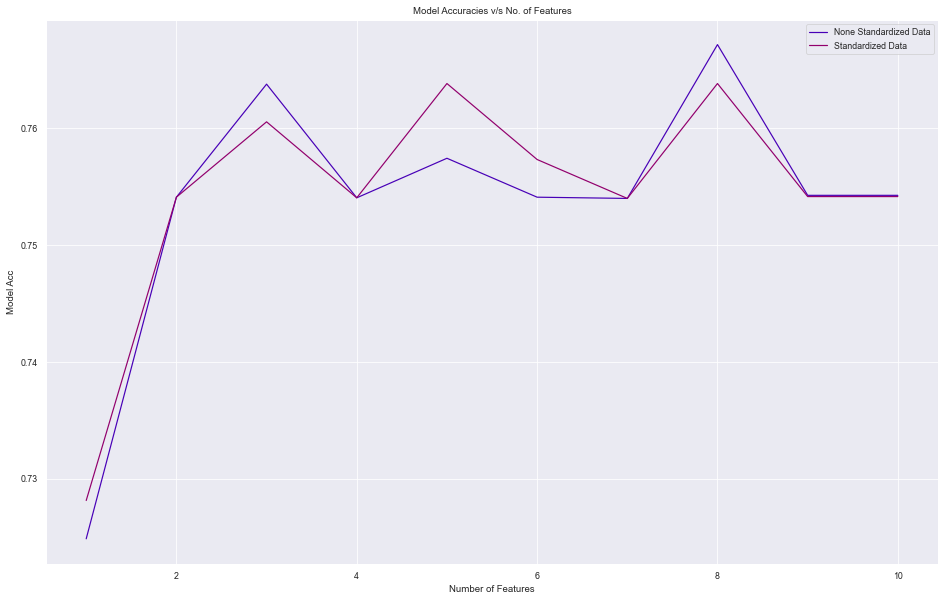

```python
plt.figure(figsize=(16,10))
plot7 = sns.lineplot(x= 'Number of Features', y= 'Model Acc', data= df_removal_order, label = 'None Standardized Data').set(label = 'Model Accuracies v/s No. of Features')
plot7 = sns.lineplot(x= 'Number of Features', y= 'Model Acc', data= df_removal_order_std, label = 'Standardized Data').set(title = 'Model Accuracies v/s No. of Features')
```

The standardization has mostly generalized the performance of all the models that were created and trained with almost all the features indiividually.

## Part 5: Decision Tree Classifier [1 Mark]

Train a decision tree classifier on the standardized dataset (read the [documentation](https://scikit-learn.org/stable/modules/generated/sklearn.tree.DecisionTreeClassifier.html) and check the example there.) Tune the `max_depth` and `min_samples_split` parameters of the tree using cross-validation (CV).

- Compare the decision tree's performance (mean CV score) with KNN, both using all the features.

```python
dt_g = tree.DecisionTreeClassifier(random_state=0)
# dt_r = tree.DecisionTreeClassifier(random_state=0)
```

```python
depth = [i for i in range(1,100,1)]
samples = [i for i in range(2,100,1)]
params = {'max_depth': depth,
          'min_samples_split': samples}
```

```python
GS = model_selection.GridSearchCV(estimator = dt_g,
                                  param_grid = params,
                                  n_jobs = -1,
                                  cv = 5,
                                  verbose = 1,
                                  error_score = 'raise')

# RS = model_selection.RandomizedSearchCV(estimator = dt_r,
#                                         param_distributions = params,
#                                         n_iter = 1000,
#                                         n_jobs = -1,
#                                         cv = 5,
#                                         verbose = 1,
#                                         error_score = 'raise')
```

```python
GS.fit(X_train_std, y_train)
```

```
Fitting 5 folds for each of 9702 candidates, totalling 48510 fits
```

```
GridSearchCV(cv=5, error_score='raise',
             estimator=DecisionTreeClassifier(random_state=0), n_jobs=-1,
             param_grid={'max_depth': [1, 2, 3, 4, 5, 6, 7, 8, 9, 10, 11, 12,
                                       13, 14, 15, 16, 17, 18, 19, 20, 21, 22,
                                       23, 24, 25, 26, 27, 28, 29, 30, ...],
                         'min_samples_split': [2, 3, 4, 5, 6, 7, 8, 9, 10, 11,
                                               12, 13, 14, 15, 16, 17, 18, 19,
                                               20, 21, 22, 23, 24, 25, 26, 27,
                                               28, 29, 30, 31, ...]},
             verbose=1)
```

```python
# RS.fit(X_train_std, y_train)
```

```python
# print('Best Parameter using Randomized Search: ', RS.best_params_, end='\n')
# print('Best Score using Randomized Search: ', RS.best_score_)
```

```python
print('Best Parameter using Grid Search: ', GS.best_params_, end='\n\n')
print('Best Validation Score using Grid Search: ', GS.best_score_)
print('Best Validation Score using KNN: 0.754151242728715')
```

```
Best Parameter using Grid Search:  {'max_depth': 5, 'min_samples_split': 71}

Best Validation Score using Grid Search:  0.7474352194606029
Best Validation Score using KNN: 0.754151242728715
```

## Part 6: Test Data [0.5 Mark]

Now that you've created several models, pick your best one (highest CV accuracy) and apply it to the test dataset you had initially set aside. Discuss your results.

```python
X_train_std_best = df_train_std[['s5', 's2', 'bmi', 's3', 'age', 'bp']].to_numpy()
X_test_std_best = df_test_std[['s5', 's2', 'bmi', 's3', 'age', 'bp']].to_numpy()
```

```python
knn = neighbors.KNeighborsClassifier(n_neighbors=77)
scores = cross_validate(knn, X_train_std_best, y_train, cv=5, return_train_score=True)
print('Train set accuracy: ', scores['train_score'].mean() * 100, '%')
print('Validation set accuracy:', scores['test_score'].mean() * 100, '%')


# Best Model available trained
model = knn.fit(X_train_std_best, y_train)
```

```
Train set accuracy:  74.59612119629097 %
Validation set accuracy: 76.38286620835537 %
```

```python
# Testing the model on Test Set
y_pred = model.predict(X_test_std_best)

# Finding the accuracy of the model
accuracy = metrics.accuracy_score(y_test, y_pred)
print ("Test set accuracy: ", accuracy * 100, "%")
```

```
Test set accuracy:  77.44360902255639 %
```

Fitting the same model on **Test data and predicting the result**, it gave an `accuracy of 77.44%.`

References:

https://towardsdatascience.com/decision-trees-in-machine-learning-641b9c4e8052

https://www.analyticsvidhya.com/blog/2021/02/machine-learning-101-decision-tree-algorithm-for-classification/